# Accounting Project

Study Group 6

10/03/2022

```r
library(tidyverse)
library(here)
library(janitor)
library(lubridate)
library(patchwork)
```

# Load data

```r
# import data
overheads <- readxl::read_excel(here("Data","Overheads.xlsx"))
transactions <- read.delim(here("Data","Transactions.txt"))
```

# Data Cleaning

```r
unique(transactions$region)
```

```
##  [1] "Midwest"       "Northwest"     "West"          "Northeast"
##  [5] "East coast"    "Central"       "South"         "International"
##  [9] "Centrall"      "Soouth"
```

```r
transactions[transactions$region == "Centrall", "region"] <-"Central"
transactions[transactions$region == "Soouth", "region"] <-"South"
```

```r
# clean data
transactions$quantity_sold<- as.numeric(transactions$quantity_sold)
transactions$date_of_sale<-lubridate::as_date(transactions$date_of_sale, format = '%d/%m/%Y')
transactions <- transactions %>%
  mutate(across(c(list_price,cost), ~gsub("\\$", "", .) %>% as.numeric))
head(transactions)
```

```
##   customer_number    region date_of_sale      item             brand collection
## 1           20943   Midwest   2015-01-01     918DP Jeffrey Alexander   Prestige
## 2          126101 Northwest   2015-01-01    2981AB          Elements   Florence
## 3          161675      West   2015-01-01 910-128PC Jeffrey Alexander     Modena
## 4          175749      West   2015-01-01 351-128PC          Elements   Calloway
## 5          216582      West   2015-01-01  S271-3PB          Elements     Torino
## 6          272896 Northeast   2015-01-01 293-160PC Jeffrey Alexander       Zane
##      description list_price  cost quantity_sold
## 1           Knob      14.14  8.62           434
## 2        3" pull       6.83  4.27            54
## 3 128 mm CC pull      17.68 11.08           450
## 4   128" CC pull       7.63  4.85           467
## 5     3" CC pull       2.52  1.60           380
## 6 160 mm CC pull      17.15 10.77           689
```

```r
overheads<-rename(overheads, category = `For the year 2018`)
```

# Question 1

```r
# calculate overhead costs in 2018
overheads %>%  pivot_longer(2:9,names_to = "region", values_to = "overheads") %>%
  pivot_wider(names_from = "category", values_from = "overheads") %>% #separate production and non-production costs in different columns
  clean_names() %>%
  summarise(production_overheads = sum(production_overheads),
            non_production_overheads = sum(non_production_overheads))  #summing up
```

```
## # A tibble: 1 × 2
##   production_overheads non_production_overheads
##                  <dbl>                    <dbl>
## 1             48205754                  9580000
```

```r
# calculate sales revenue and costs
transactions <-transactions %>%
  mutate(sales_revenue = list_price*quantity_sold,
         costs = cost*quantity_sold,
         year = year(date_of_sale))

# calculate operating profits and percentage in sales
transactions %>% filter(year == 2018) %>%
  summarise(sales_revenue = sum(sales_revenue),
            costs = sum(costs)) %>%
  mutate(gross_profits = sales_revenue-costs-48205754) %>%
  mutate(operating_profit = gross_profits-9580000) %>% # subtract non-production overhead costs
  mutate(profit_as_percentage_of_sales = operating_profit/sales_revenue)
```

```
##   sales_revenue    costs gross_profits operating_profit
## 1     154984988 94618794      12160440          2580440
##   profit_as_percentage_of_sales
## 1                    0.01664961
```

# Question 2

By calculating and plotting the operating profits of each region, we found that the Eastcoast region has the highest operating profits, as shown by the bar chart in figure 1. The West and South regions are suffering negative operating profits. By looking at figure 2, we see that the West region has a positive gross profits, which suggests that its non-production overheads must be higher than gross profits so that it brings the operating profits to a negative number.

```r
# calculate overhead costs in 2018
overheads_by_region <- overheads %>%
  pivot_longer(2:9,names_to = "region", values_to = "overheads") %>%
  pivot_wider(names_from = "category", values_from = "overheads") %>% #separate production and non-production costs in different columns
  clean_names()
overheads_by_region
```

```
## # A tibble: 8 × 3
##   region        production_overheads non_production_overheads
##   <chr>                        <dbl>                    <dbl>
## 1 Central                    5278312                  1219464
## 2 East coast                 7513545                  1589821
## 3 International               690587                   217290
## 4 Midwest                    9874330                  2018055
## 5 Northeast                  3965187                   814835
## 6 Northwest                  4968774                  1075209
## 7 South                      6849541                   980076
## 8 West                       9065478                  1665250
```

```r
transactions_by_region <- transactions %>%
  filter(year == 2018) %>%
  group_by(region) %>%
  summarise(sales_revenue = sum(sales_revenue),
            costs = sum(costs))
transactions_by_region
```

```
## # A tibble: 8 × 3
##   region        sales_revenue     costs
##   <chr>                 <dbl>     <dbl>
## 1 Central           19728444. 12526495
## 2 East coast        25720078. 15615559.
## 3 International      3515301.  2139543.
## 4 Midwest           32648041. 19821850.
## 5 Northeast         13182393.  8020092.
## 6 Northwest         17394723. 10510174.
## 7 South             15855649.  9661517.
## 8 West              26940358. 16323564.
```

```r
joined_by_region <- full_join(overheads_by_region, transactions_by_region, by = "region")
joined_by_region <- joined_by_region %>%
  mutate(gross_profits = sales_revenue-costs-production_overheads) %>%
  mutate(operating_profits = sales_revenue-costs-production_overheads-non_production_overheads)
head(joined_by_region)
```

```
## # A tibble: 6 × 7
##   region  production_overh… non_production_o… sales_revenue  costs gross_profits
##   <chr>               <dbl>             <dbl>         <dbl>  <dbl>         <dbl>
## 1 Central           5278312           1219464     19728444. 1.25e7      1923638.
## 2 East c…           7513545           1589821     25720078. 1.56e7      2590974.
## 3 Intern…            690587            217290      3515301. 2.14e6       685172.
## 4 Midwest           9874330           2018055     32648041. 1.98e7      2951861.
## 5 Northe…           3965187            814835     13182393. 8.02e6      1197114.
## 6 Northw…           4968774           1075209     17394723. 1.05e7      1915774.
## # … with 1 more variable: operating_profits <dbl>
```

## Figure 1- Operating Profits by Region

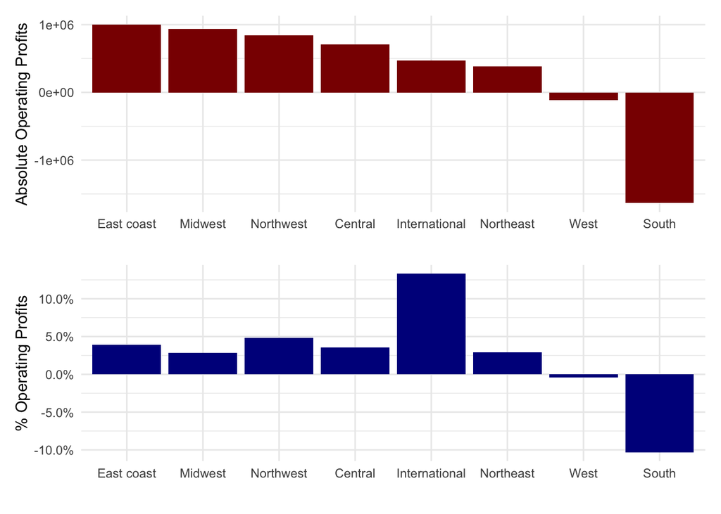

```r
(joined_by_region %>%
  ggplot(aes(x = fct_reorder(region, -operating_profits), y = operating_profits)) +
  geom_col(fill = "darkred") +
  labs(x = "", y = "Absolute Operating Profits") +
  theme_minimal()) / (joined_by_region %>%
  ggplot(aes(x = fct_reorder(region, -operating_profits), y = operating_profits/sales_revenue)) +
  geom_col(fill = "darkblue") +
  scale_y_continuous(labels = scales::percent) +
  labs(x = "", y = "% Operating Profits") +
  theme_minimal())
```

## Figure 2- Gross Profits by Region

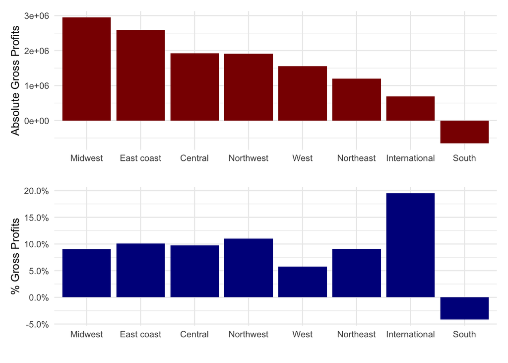

```r
(joined_by_region %>%
  ggplot(aes(x = fct_reorder(region, -gross_profits), y = gross_profits)) +
  geom_col(fill = "darkred") +
  labs(x = "", y = "Absolute Gross Profits") +
  theme_minimal()) / (joined_by_region %>%
  ggplot(aes(x = fct_reorder(region, -gross_profits), y = gross_profits/sales_revenue)) +
  geom_col(fill = "darkblue") +
  scale_y_continuous(labels = scales::percent) +
  labs(x = "", y = "% Gross Profits") +
  theme_minimal())
```

## Figure 3- Cost Breakdown by Region

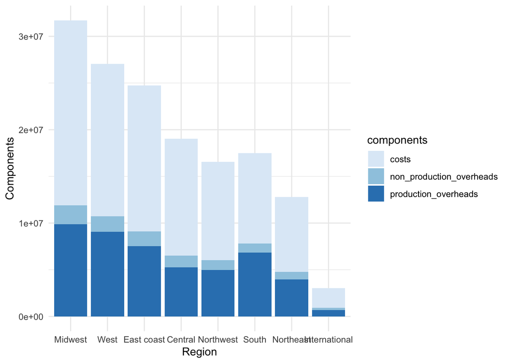

```r
joined_by_region %>% pivot_longer(c(2,3,5), names_to = "components", values_to = "value") %>%
ggplot(aes(x = fct_rev(fct_reorder(region, sales_revenue)), y = value, fill = components)) +
  geom_bar(stat = "identity") +
  labs(x = "Region", y = "Components")+
  theme_minimal() +
  scale_fill_brewer(palette = "Blues")
```

## Figure 4- Cost Breakdown in Percentage by Region

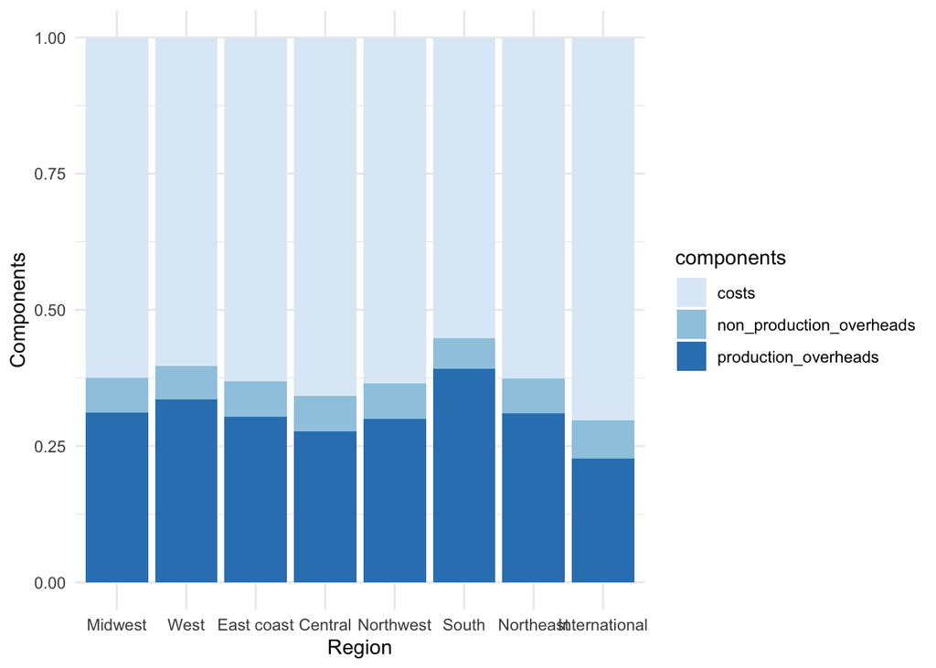

```r
joined_by_region %>% pivot_longer(c(2,3,5), names_to = "components", values_to = "value") %>%
ggplot(aes(x = fct_rev(fct_reorder(region, sales_revenue)), y = value, fill = components)) +
  geom_bar(stat = "identity", position = "fill") +
  labs(x = "Region", y = "Components") +
  theme_minimal() +
  scale_fill_brewer(palette = "Blues")
```

# Question 3

As shown in figure 1 and 2, both sales revenue and contribution margin are higher for Jefferey Alexander brand. The difference in sales revenue is very large, which means that Jefferey Alexander is much more competitive in market than Elements. From figure 3, we see that for different collections, there is a positive relationship between sales revenue and contribution margin, which holds true for both brands.

From figure 4, we see that Belcastel contributed the most sales revenue and contribution margin to the Jefferey Alexander brand, while Madison contributed the most to the Elements brand.

```r
joined_by_region <- joined_by_region %>%
  mutate(pro_overhead_per_sales = production_overheads/sales_revenue)

transactions_by_brand <- transactions %>%
  left_join(joined_by_region %>% select(region, pro_overhead_per_sales), by = "region") %>%
  mutate(production_overheads = pro_overhead_per_sales*sales_revenue,
         total_variable_cost = production_overheads+costs) %>%
  group_by(brand) %>%
  summarize(sales_revenue = sum(sales_revenue),
            total_variable_cost = sum(total_variable_cost)) %>%
  mutate(contribution_margin_perc = 1- (total_variable_cost/sales_revenue),
         contribution_margin = sales_revenue-total_variable_cost)
transactions_by_brand
```

```
## # A tibble: 2 × 5
##   brand     sales_revenue total_variable_c… contribution_margi… contribution_ma…
##   <chr>             <dbl>             <dbl>               <dbl>            <dbl>
## 1 Elements      81739400.         77737786.              0.0490         4001614.
## 2 Jeffrey …    403337381.        370438371.              0.0816        32899010.
```

```r
transactions_by_collection <- transactions %>%
  left_join(joined_by_region %>% select(region, pro_overhead_per_sales), by = "region") %>%
  mutate(production_overheads = pro_overhead_per_sales*sales_revenue,
         total_variable_cost = production_overheads+costs) %>%
  group_by(collection) %>%
  summarize(sales_revenue = sum(sales_revenue),
            total_variable_cost = sum(total_variable_cost)) %>%
  mutate(contribution_margin_perc = 1- (total_variable_cost/sales_revenue),
         contribution_margin = sales_revenue-total_variable_cost)
head(transactions_by_collection)
```

```
## # A tibble: 6 × 5
##   collection sales_revenue total_variable_cost contribution_ma… contribution_ma…
##   <chr>              <dbl>               <dbl>            <dbl>            <dbl>
## 1 Aberdeen        4959652.            4550959.           0.0824          408693.
## 2 Aiden            330647.            1074964.          -2.25           -744317.
## 3 Alvar           2117913.            1916725.           0.0950          201188.
## 4 Amsden          2502762.            2298731.           0.0815          204031.
## 5 Annadale        4869955.            4528855.           0.0700          341100.
## 6 Anwick          6022229.            5634367.           0.0644          387863.
```

```r
transactions_by_brand_collection <- transactions %>%
  left_join(joined_by_region %>% select(region, pro_overhead_per_sales), by = "region") %>%
  mutate(production_overheads = pro_overhead_per_sales*sales_revenue,
         total_variable_cost = production_overheads+costs) %>%
  group_by(brand,collection) %>%
  summarize(sales_revenue = sum(sales_revenue),
            total_variable_cost = sum(total_variable_cost)) %>%
  mutate(contribution_margin_perc = 1- (total_variable_cost/sales_revenue),
         contribution_margin = sales_revenue-total_variable_cost)
head(transactions_by_brand_collection)
```

```
## # A tibble: 6 × 6
## # Groups:   brand [1]
##   brand    collection sales_revenue total_variable_cost contribution_margin_perc
##   <chr>    <chr>              <dbl>               <dbl>                    <dbl>
## 1 Elements Aiden            330647.            1074964.                  -2.25
## 2 Elements Arcadia         1219833.            1160922.                   0.0483
## 3 Elements Asher           3016359.            2859747.                   0.0519
## 4 Elements Belfast         2407136.            2313362.                   0.0390
## 5 Elements Brenton         3784927.            3547444.                   0.0627
## 6 Elements Calloway        2989323.            2809301.                   0.0602
## # … with 1 more variable: contribution_margin <dbl>
```

## Figure 1

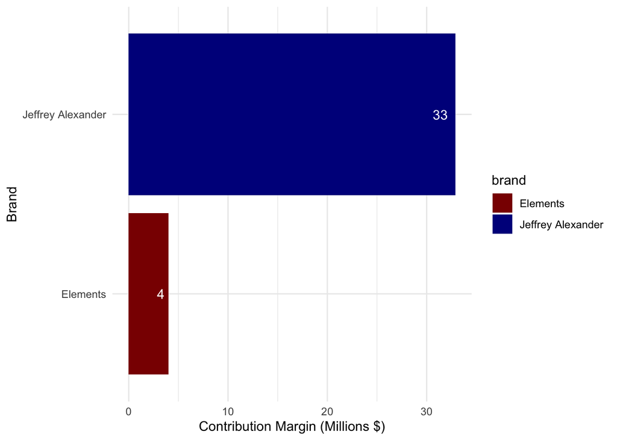

```r
transactions_by_brand %>% ggplot(aes(x = contribution_margin/1000000, y = brand, fill = brand)) +
  geom_col() +
  geom_text(aes(label = round(contribution_margin/1000000)),  hjust = 1.5, color = '#ffffff') +
  scale_fill_manual(values = c("darkred", "darkblue"))+
  labs(x = "Contribution Margin (Millions $)", y = "Brand") +
  theme_minimal()
```

## Figure 2

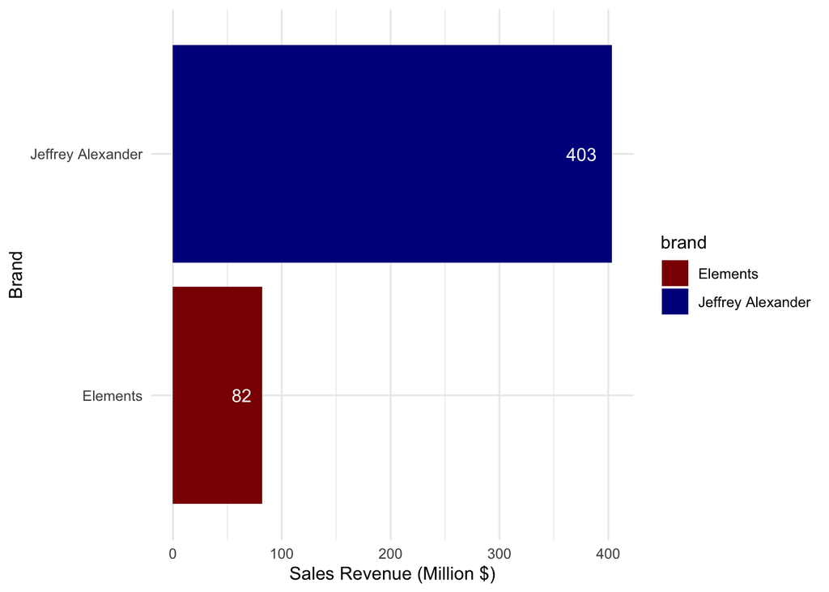

```r
transactions_by_brand %>% ggplot(aes(x = sales_revenue/1000000, y = brand, fill = brand)) +
  geom_col() +
  geom_text(aes(label = round(sales_revenue/1000000)), hjust = 1.5, color = '#ffffff') +
  scale_fill_manual(values = c("darkred", "darkblue"))+
  labs(x = "Sales Revenue (Million $)", y = "Brand") +
  theme_minimal()
```

## Figure 3

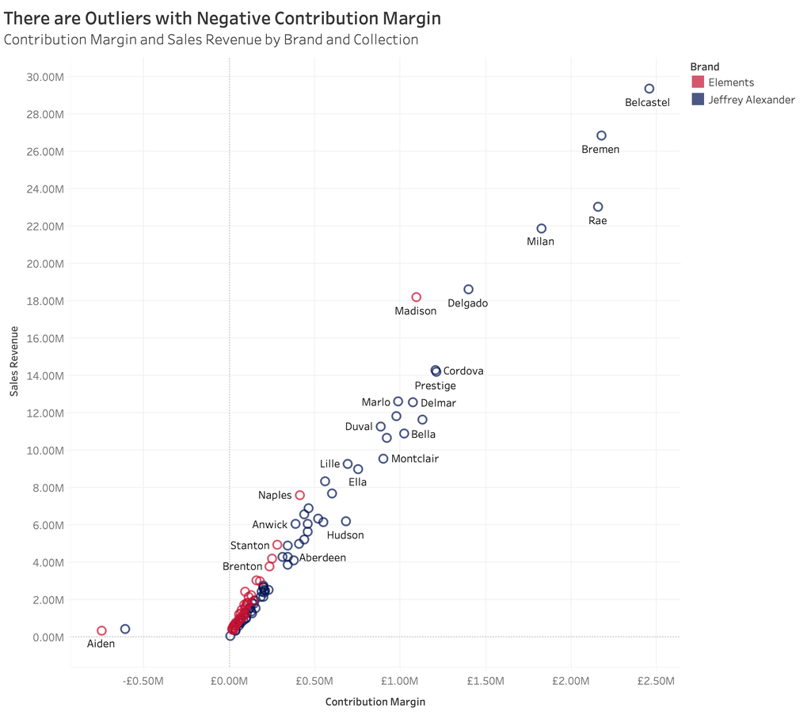

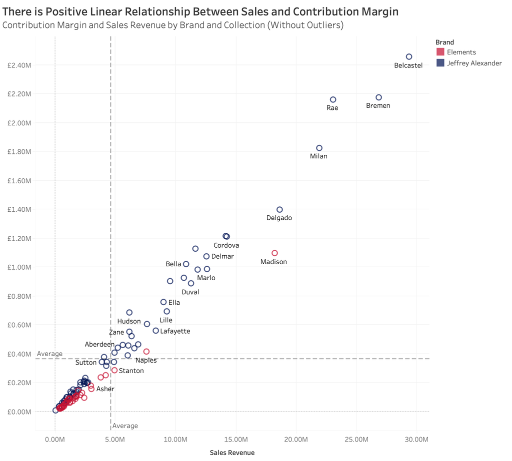

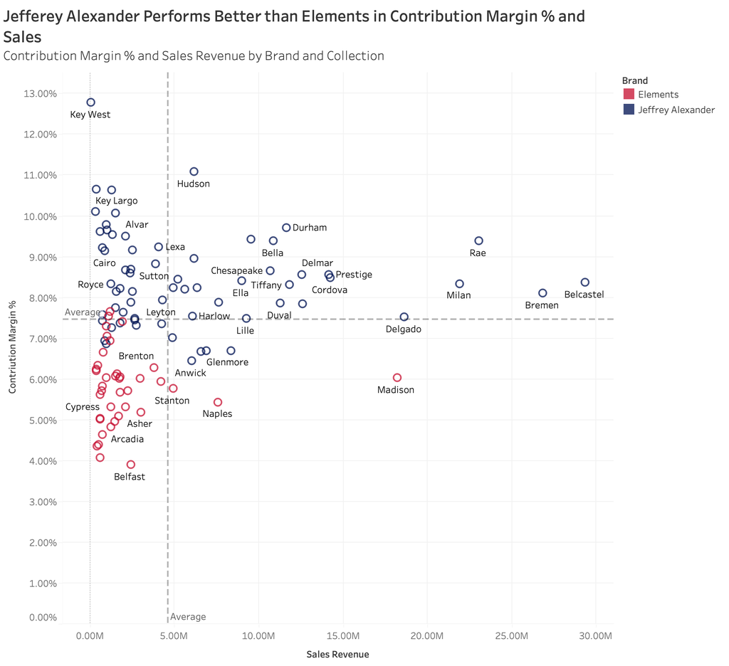

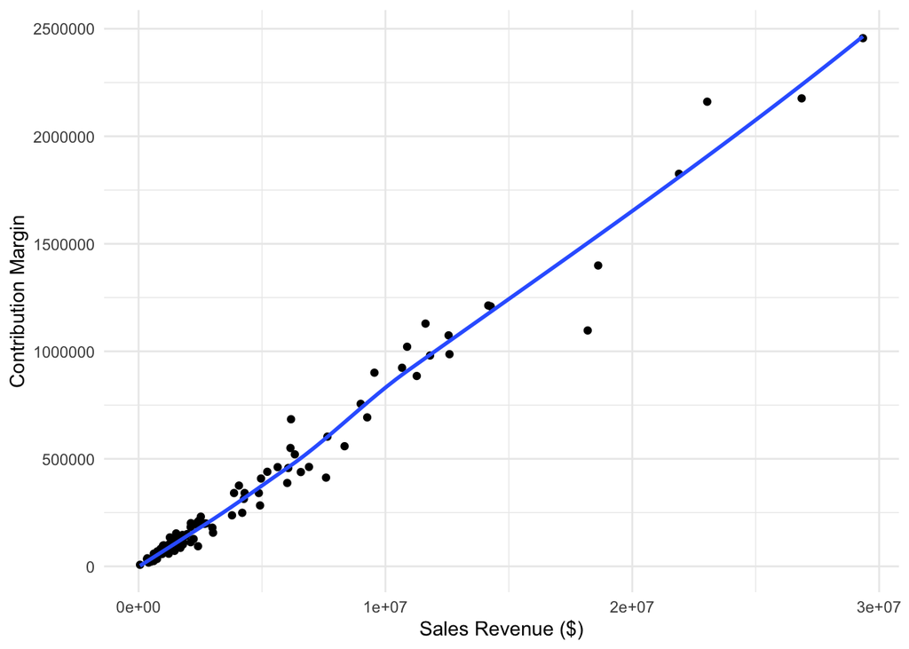

```r
# transactions_by_collection %>% ggplot(aes(x = sales_revenue, y = contribution_margin)) +
#   geom_point()

transactions_by_brand_collection %>% filter(contribution_margin > 0) %>% ggplot(aes(x = sales_revenue, y = contribution_margin)) +
  geom_point() +
  geom_smooth(se = FALSE)+
  scale_fill_manual(values = c("darkred", "darkblue"))+
  labs(x = "Sales Revenue ($)", y = "Contribution Margin") +
  theme_minimal()
```

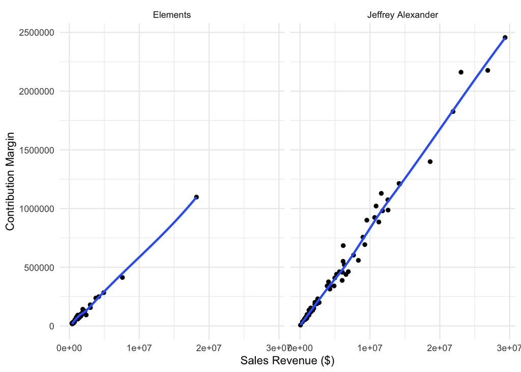

```r
transactions_by_brand_collection %>% filter(contribution_margin > 0) %>% ggplot(aes(x = sales_revenue, y = contribution_margin)) +
  geom_point() +
  geom_smooth(se = FALSE) +
  facet_wrap(~brand)+
  labs(x = "Sales Revenue ($)", y = "Contribution Margin") +
  theme_minimal()
```

## Figure 4

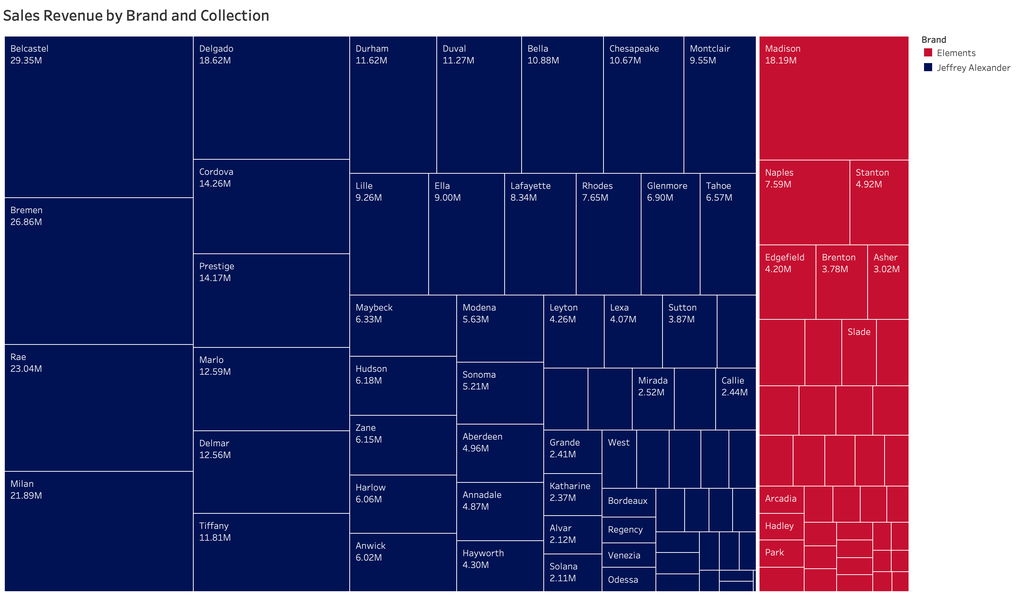

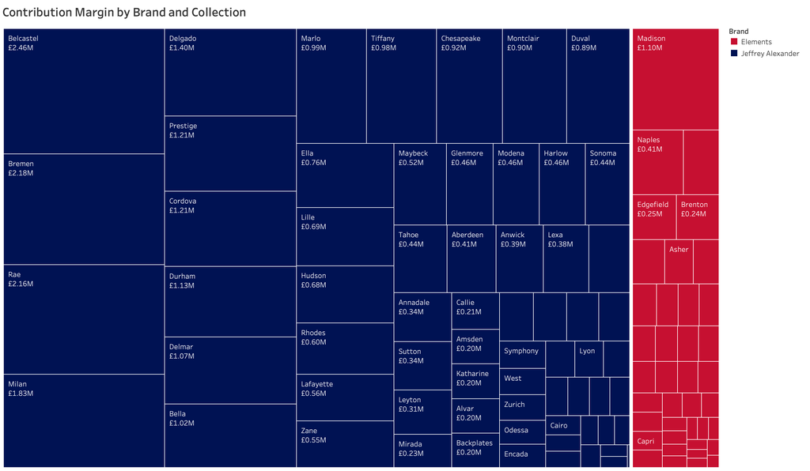

## Figure 5

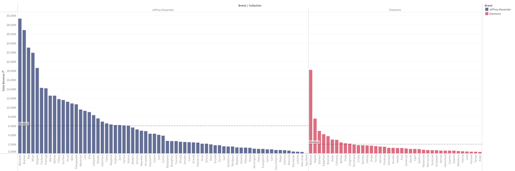

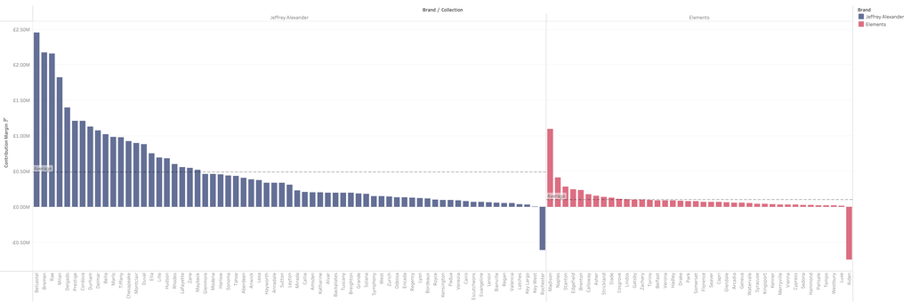

# Question 4

We choose to find the breakeven sales and volume by chronological order of transactions.

## Overall

```r
transactions_variableCost <- transactions %>%
  filter(year == 2018) %>%
  arrange(date_of_sale) %>%
  left_join(joined_by_region %>% select(region, pro_overhead_per_sales), by = "region") %>%
  mutate(total_variable_cost = costs + pro_overhead_per_sales*sales_revenue)

break_even <- data.frame(total_cost = cumsum(transactions_variableCost$total_variable_cost) + sum(joined_by_region$non_production_overheads),
                         sales_revenue = cumsum(transactions_variableCost$sales_revenue),
                         volume = cumsum(transactions_variableCost$quantity_sold),
                         date = transactions_variableCost$date_of_sale)

break_even[which(break_even$total_cost <= break_even$sales_revenue)[1],]
```

```
##       total_cost sales_revenue  volume       date
## 12361  122790564     122793343 6750493 2018-10-21
```

Overall, the company manage to breakeven at 2018-10-21 with a breakeven sales revenue of 122.79 million and a breakeven sales volume of 6.75 million.

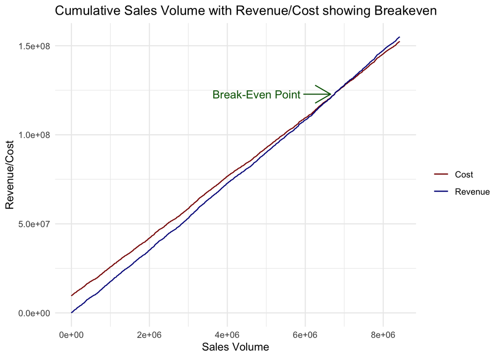

```r
ggplot(break_even, aes(x = volume)) +
  geom_line(aes(y = total_cost, color = "Cost")) +
  geom_line(aes(y = sales_revenue, color = "Revenue")) +
  annotate("text",
           x = break_even[which(break_even$total_cost <= break_even$sales_revenue)[1],][3] %>% pull() - 2000000,
           y = break_even[which(break_even$total_cost <= break_even$sales_revenue)[1],][2] %>% pull(),
           label = "Break-Even Point",
           size = 4,
           color = "darkgreen") +
  annotate("segment",
           x = break_even[which(break_even$total_cost <= break_even$sales_revenue)[1],][3] %>% pull() - 800000,
           xend = break_even[which(break_even$total_cost <= break_even$sales_revenue)[1],][3] %>% pull() - 100000,
           y = break_even[which(break_even$total_cost <= break_even$sales_revenue)[1],][2] %>% pull(),
           yend = break_even[which(break_even$total_cost <= break_even$sales_revenue)[1],][2] %>% pull(),
           arrow = arrow(),
           size = 0.5,
           color = "darkgreen") +
  scale_colour_manual("",
                      breaks = c("Cost", "Revenue"),
                      values = c("darkred", "darkblue")) +
  theme_minimal() +
  labs(title = "Cumulative Sales Volume with Revenue/Cost showing Breakeven",
       x = "Sales Volume",
       y = "Revenue/Cost")
```

## Regional

```r
unique(transactions_variableCost$region)
```

```
## [1] "Northeast"     "East coast"    "Midwest"       "Central"
## [5] "West"          "South"         "Northwest"     "International"
```

```r
transactions_variableCost_Northeast <- transactions_variableCost %>% filter(region == "Northeast")
break_even_Northeast <- data.frame(total_cost = cumsum(transactions_variableCost_Northeast$total_variable_cost) + (overheads[2,"Northeast"] %>% pull()),
                         sales_revenue = cumsum(transactions_variableCost_Northeast$sales_revenue),
                         volume = cumsum(transactions_variableCost_Northeast$quantity_sold),
                         date = transactions_variableCost_Northeast$date_of_sale)

transactions_variableCost_Eastcoast <- transactions_variableCost %>% filter(region == "East coast")
break_even_Eastcoast <- data.frame(total_cost = cumsum(transactions_variableCost_Eastcoast$total_variable_cost) + (overheads[2,"East coast"] %>% pull()),
                         sales_revenue = cumsum(transactions_variableCost_Eastcoast$sales_revenue),
                         volume = cumsum(transactions_variableCost_Eastcoast$quantity_sold),
                         date = transactions_variableCost_Eastcoast$date_of_sale)

transactions_variableCost_Midwest <- transactions_variableCost %>% filter(region == "Midwest")
break_even_Midwest <- data.frame(total_cost = cumsum(transactions_variableCost_Midwest$total_variable_cost) + (overheads[2,"Midwest"] %>% pull()),
                         sales_revenue = cumsum(transactions_variableCost_Midwest$sales_revenue),
                         volume = cumsum(transactions_variableCost_Midwest$quantity_sold),
                         date = transactions_variableCost_Midwest$date_of_sale)

transactions_variableCost_Central <- transactions_variableCost %>% filter(region == "Central")
break_even_Central <- data.frame(total_cost = cumsum(transactions_variableCost_Central$total_variable_cost) + (overheads[2,"Central"] %>% pull()),
                         sales_revenue = cumsum(transactions_variableCost_Central$sales_revenue),
                         volume = cumsum(transactions_variableCost_Central$quantity_sold),
                         date = transactions_variableCost_Central$date_of_sale)

transactions_variableCost_West <- transactions_variableCost %>% filter(region == "West")
break_even_West <- data.frame(total_cost = cumsum(transactions_variableCost_West$total_variable_cost) + (overheads[2,"West"] %>% pull()),
                         sales_revenue = cumsum(transactions_variableCost_West$sales_revenue),
                         volume = cumsum(transactions_variableCost_West$quantity_sold),
                         date = transactions_variableCost_West$date_of_sale)

transactions_variableCost_South <- transactions_variableCost %>% filter(region == "South")
break_even_South <- data.frame(total_cost = cumsum(transactions_variableCost_South$total_variable_cost) + (overheads[2,"South"] %>% pull()),
                         sales_revenue = cumsum(transactions_variableCost_South$sales_revenue),
                         volume = cumsum(transactions_variableCost_South$quantity_sold),
                         date = transactions_variableCost_South$date_of_sale)

transactions_variableCost_Northwest <- transactions_variableCost %>% filter(region == "Northwest")
break_even_Northwest <- data.frame(total_cost = cumsum(transactions_variableCost_Northwest$total_variable_cost) + (overheads[2,"Northwest"] %>% pull()),
                         sales_revenue = cumsum(transactions_variableCost_Northwest$sales_revenue),
                         volume = cumsum(transactions_variableCost_Northwest$quantity_sold),
                         date = transactions_variableCost_Northwest$date_of_sale)

transactions_variableCost_International <- transactions_variableCost %>% filter(region == "International")
break_even_International <- data.frame(total_cost = cumsum(transactions_variableCost_International$total_variable_cost) + (overheads[2,"International"] %>% pull()),
                         sales_revenue = cumsum(transactions_variableCost_International$sales_revenue),
                         volume = cumsum(transactions_variableCost_International$quantity_sold),
                         date = transactions_variableCost_International$date_of_sale)

break_even_region <- data.frame(
  region = unique(transactions_variableCost$region),
  break_even_date = c(break_even_Northeast[which(break_even_Northeast$total_cost <= break_even_Northeast$sales_revenue)[1],][4] %>% pull(),
                      break_even_Eastcoast[which(break_even_Eastcoast$total_cost <= break_even_Eastcoast$sales_revenue)[1],][4] %>% pull(),
                      break_even_Midwest[which(break_even_Midwest$total_cost <= break_even_Midwest$sales_revenue)[1],][4] %>% pull(),
                      break_even_Central[which(break_even_Central$total_cost <= break_even_Central$sales_revenue)[1],][4] %>% pull(),
                      break_even_West[which(break_even_West$total_cost <= break_even_West$sales_revenue)[1],][4] %>% pull(),
                      break_even_South[which(break_even_South$total_cost <= break_even_South$sales_revenue)[1],][4] %>% pull(),
                      break_even_Northwest[which(break_even_Northwest$total_cost <= break_even_Northwest$sales_revenue)[1],][4] %>% pull(),
                      break_even_International[which(break_even_International$total_cost <= break_even_International$sales_revenue)[1],][4] %>% pull()),
  break_even_sales = c(break_even_Northeast[which(break_even_Northeast$total_cost <= break_even_Northeast$sales_revenue)[1],][2] %>% pull(),
                       break_even_Eastcoast[which(break_even_Eastcoast$total_cost <= break_even_Eastcoast$sales_revenue)[1],][2] %>% pull(),
                       break_even_Midwest[which(break_even_Midwest$total_cost <= break_even_Midwest$sales_revenue)[1],][2] %>% pull(),
                       break_even_Central[which(break_even_Central$total_cost <= break_even_Central$sales_revenue)[1],][2] %>% pull(),
                       break_even_West[which(break_even_West$total_cost <= break_even_West$sales_revenue)[1],][2] %>% pull(),
                       break_even_South[which(break_even_South$total_cost <= break_even_South$sales_revenue)[1],][2] %>% pull(),
                       break_even_Northwest[which(break_even_Northwest$total_cost <= break_even_Northwest$sales_revenue)[1],][2] %>% pull(),
                       break_even_International[which(break_even_International$total_cost <= break_even_International$sales_revenue)[1],][2] %>% pull()),
  break_even_quantity = c(break_even_Northeast[which(break_even_Northeast$total_cost <= break_even_Northeast$sales_revenue)[1],][3] %>% pull(),
                          break_even_Eastcoast[which(break_even_Eastcoast$total_cost <= break_even_Eastcoast$sales_revenue)[1],][3] %>% pull(),
                          break_even_Midwest[which(break_even_Midwest$total_cost <= break_even_Midwest$sales_revenue)[1],][3] %>% pull(),
                          break_even_Central[which(break_even_Central$total_cost <= break_even_Central$sales_revenue)[1],][3] %>% pull(),
                          break_even_West[which(break_even_West$total_cost <= break_even_West$sales_revenue)[1],][3] %>% pull(),
                          break_even_South[which(break_even_South$total_cost <= break_even_South$sales_revenue)[1],][3] %>% pull(),
                          break_even_Northwest[which(break_even_Northwest$total_cost <= break_even_Northwest$sales_revenue)[1],][3] %>% pull(),
                          break_even_International[which(break_even_International$total_cost <= break_even_International$sales_revenue)[1],][3] %>% pull())
  )
break_even_region
```

```
##          region break_even_date break_even_sales break_even_quantity
## 1     Northeast      2018-09-15          8903799              431546
## 2    East coast      2018-08-26         15702736              794605
## 3       Midwest      2018-09-10         22069107             1130497
## 4       Central      2018-09-01         12686386             1266387
## 5          West            <NA>               NA                  NA
## 6         South            <NA>               NA                  NA
## 7     Northwest      2018-08-05          9650867              470358
## 8 International      2018-04-08          1083576               46049
```

As we can see, most regions break even in between August and September but only two regions “West” and “South” did not break even. The region “International” broke even very early in the year only at April.

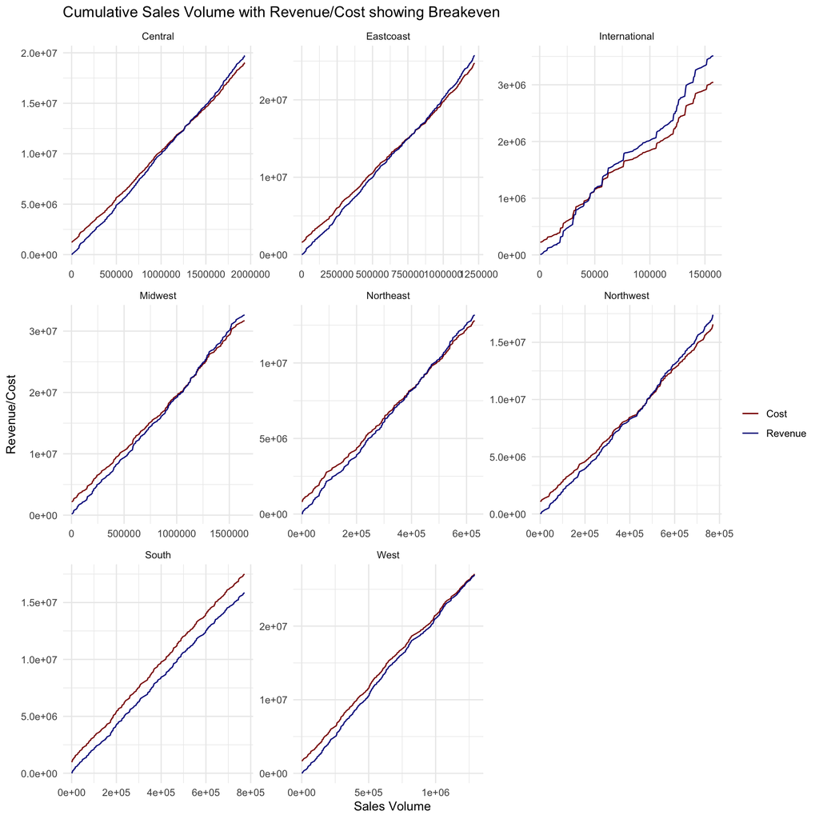

```r
break_even_Northeast %>%
  mutate(region = "Northeast") %>%
  rbind(break_even_Eastcoast %>% mutate(region = "Eastcoast")) %>%
  rbind(break_even_Midwest %>% mutate(region = "Midwest")) %>%
  rbind(break_even_Central %>% mutate(region = "Central")) %>%
  rbind(break_even_West %>% mutate(region = "West")) %>%
  rbind(break_even_South %>% mutate(region = "South")) %>%
  rbind(break_even_Northwest %>% mutate(region = "Northwest")) %>%
  rbind(break_even_International %>% mutate(region = "International")) %>%
  select(-date) %>%
  ggplot(aes(x = volume)) +
    geom_line(aes(y = total_cost, color = "Cost")) +
    geom_line(aes(y = sales_revenue, color = "Revenue")) +
    scale_colour_manual("",
                        breaks = c("Cost", "Revenue"),
                        values = c("darkred", "darkblue")) +
    facet_wrap(~region, scales = "free") +
    theme_minimal() +
    labs(title = "Cumulative Sales Volume with Revenue/Cost showing Breakeven",
         x = "Sales Volume",
         y = "Revenue/Cost")
```

# Question 5

## a)

Cost absorption is an approach of allocating fixed overhead costs to each unit of a product produced in the same period when the fixed overhead cost is made. This disregards when the produced good is actually sold.

With the data provided, we only know when products are sold but has no information on when it is produced. However, we can make an assumption that the company uses made to order policy and hence the sales is made when the product is produced. Similar to above, we will split the regional overhead costs by regional sales revenue of each transaction.

```r
joined_by_region <- joined_by_region %>%
  mutate(overhead_per_sales = (production_overheads+non_production_overheads)/sales_revenue)

transactions_by_brand_collection <- transactions %>%
  filter(year == 2018) %>%
  left_join(joined_by_region %>% select(region, overhead_per_sales), by = "region") %>%
  mutate(overheads = overhead_per_sales*sales_revenue,
         total_cost = overheads+costs) %>%
  group_by(brand,collection) %>%
  summarize(total_cost = sum(total_cost))
transactions_by_brand_collection
```

```
## # A tibble: 107 × 3
## # Groups:   brand [2]
##    brand    collection total_cost
##    <chr>    <chr>           <dbl>
##  1 Elements Aiden         328333.
##  2 Elements Arcadia       384968.
##  3 Elements Asher         808282.
##  4 Elements Belfast       885453.
##  5 Elements Brenton      1191983.
##  6 Elements Calloway      870604.
##  7 Elements Capri         272849.
##  8 Elements Cosgrove      691912.
##  9 Elements Cypress       145605.
## 10 Elements Drake         496568.
## # … with 97 more rows
```

## b)

Our full cost estimations could be improved if we can know about when the products of each transactions are produced and hence allocate the fixed cost according to their production date instead of date of sales.

If detailed information about each products are hard to gather, mean inventory holding period of each product or turnover rate could also be used to make a rough estimate of when each product is produced.